# Gestão de Branding no Agro

Aula 06 — Ideias Diferenciadoras no Agronegócio  
Terroir, Processo, Origem e Impacto

Luiz Diego Vidal Santos

## Visão Geral

### Tópicos Principais

- 1 Categorias de ideias diferenciadoras
- 2 Diferenciação por origem e terroir
- 3 Diferenciação por método de produção
- 4 Diferenciação por propósito e impacto
- 5 Avaliação e seleção de diferenciais

**Objetivo da Aula**

Explorar as principais categorias de diferenciação aplicáveis ao agro e aprender a selecionar as ideias diferenciadoras mais promissoras.

## AS 8 CATEGORIAS DE DIFERENCIAÇÃO NO AGRO

| # | Categoria | Pergunta-chave |
| --- | --- | --- |
| 1 | **Origem** | De onde vem? |
| 2 | **Processo** | Como é feito? |
| 3 | **Especialização** | Em que somos especialistas? |
| 4 | **Pioneirismo** | Fomos os primeiros em quê? |
| 5 | **Preferência** | O que o mercado já prefere em nós? |
| 6 | **Tradição** | Há quanto tempo fazemos isso? |
| 7 | **Tecnologia** | Que inovação empregamos? |
| 8 | **Propósito** | Por que fazemos o que fazemos? |

Cada uma gera um tipo diferente de vantagem competitiva.

## 1. DIFERENCIAÇÃO POR ORIGEM

A origem é o diferencial mais natural do agro — o solo, o clima, a altitude e a água criam produtos **únicos e irreproduzíveis**.

**Elementos de origem:**

- Localização geográfica e microclima
- Tipo de solo e composição mineral
- Altitude e variação térmica
- Bioma e biodiversidade circundante
- Água e recurso hídrico

**Exemplo:** O cacau de Ilhéus tem perfil sensorial diferente do cacau do Pará. Mesmo que a variedade seja idêntica, o **terroir** é inimitável.

**Tip**

Se seu produto tem ligação com o território, **a origem é seu maior patrimônio de marca**.

## 2. DIFERENCIAÇÃO POR PROCESSO

O “como é feito” pode ser tão diferenciador quanto o “o que é”:

| Processo | O que comunica |
| --- | --- |
| Colheita manual seletiva | Cuidado e qualidade |
| Secagem em terreiro suspenso | Controle artesanal |
| Fermentação natural controlada | Complexidade sensorial |
| Pastejo rotacionado | Responsabilidade ambiental |
| Maturação em adega natural | Tradição e tempo |
| Polinização por abelhas nativas | Integração ecológica |

O processo é um diferencial poderoso porque envolve **conhecimento**, **investimento** e **tempo** — três barreiras para imitadores.

## EXEMPLO: MÉTODO DE FABRICAÇÃO

[figure not shown]

A ruptura com o massificado cria valor percebido através do método de produção

## 3. DIFERENCIAÇÃO POR ESPECIALIZAÇÃO

Especialistas são percebidos como **mais confiáveis** que generalistas:

### Generalista

“Produzimos café, milho, soja e temos gado.”

- Sem foco
- Sem expertise percebida
- Dificuldade de comunicar identidade

### Especialista

“Produzimos exclusivamente café em altitude acima de 1.000m.”

- Foco claro
- Expertise percebida
- Identidade de marca forte

> Especialização não significa produzir menos — significa comunicar **expertise**.

## EXEMPLO: ESPECIALIZAÇÃO

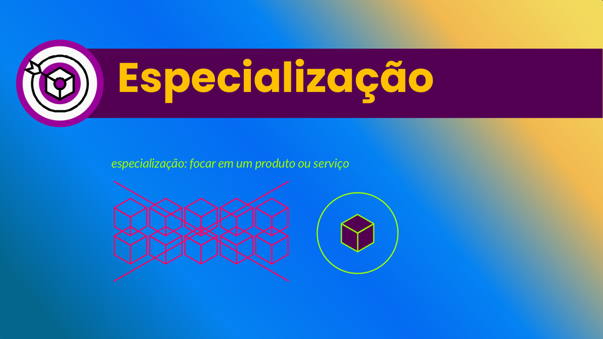

Focar em um produto ou serviço é o caminho do especialista

## 4. DIFERENCIAÇÃO POR PIONEIRISMO

Ser o primeiro em algo cria uma vantagem duradoura na mente do público:

- Primeiro produtor orgânico certificado da região
- Primeiro a rastrear lotes via QR code
- Primeiro a produzir na região com energia solar
- Primeiro a adotar pecuária regenerativa no município

**Warning**

**Atenção:** Ser primeiro só é diferencial se for **relevante** para o público. “Primeiro a ter trator vermelho” não é diferenciação — é curiosidade.

## EXEMPLO: PIONEIRISMO

[figure not shown]

O pioneirismo como ideia diferenciadora, quando a marca inaugura uma categoria

## EXEMPLO: TRADIÇÃO

[figure not shown]

A Granado como diferenciação por tradição: produtos históricos reposicionados

## 5. DIFERENCIAÇÃO POR PROPÓSITO E IMPACTO

Diferenciais de propósito respondem à pergunta: **“Por que existimos além do lucro?”**

| Tipo de impacto | Exemplo |
| --- | --- |
| **Ambiental** | Regeneração do solo, sequestro de carbono, restauração de nascentes |
| **Social** | Geração de renda para famílias rurais, fixação de jovens no campo |
| **Cultural** | Resgate de variedades crioulas, preservação de técnicas ancestrais |
| **Educacional** | Fazenda-escola, turismo rural pedagógico |

O propósito é o nível mais alto de diferenciação porque transcende o produto e cria **significado**.

## EXEMPLO: ESTRATÉGIA BOUTIQUE

[figure not shown]

Transformar o ordinário em premium pela segmentação radical

## AVALIAÇÃO DE IDEIAS DIFERENCIADORAS

Nem toda ideia diferenciadora merece investimento. Avalie cada uma:

| Critério | Peso | Nota (1-5) |
| --- | --- | --- |
| É **verdadeira**? (Posso provar?) | ★★★ |  |
| É **relevante**? (O público valoriza?) | ★★★ |  |
| É **exclusiva**? (Ninguém mais pode dizer?) | ★★ |  |
| É **sustentável**? (Mantém-se no longo prazo?) | ★★ |  |
| É **comunicável**? (Consigo explicar em 10 seg?) | ★ |  |

O diferencial ideal pontua **alto em todos os critérios**.

## EXERCÍCIO EM SALA

### Atividade: Mapeamento de Diferenciais

Para o produto agro trabalhado nas aulas anteriores:

1. Liste **todas** as possíveis ideias diferenciadoras (mínimo 8)
2. Classifique cada uma nas 8 categorias
3. Avalie cada uma com a matriz de avaliação (slide anterior)
4. Selecione as **3 mais fortes**
5. Para cada uma, escreva: “Somos o/a único(a) _____ que _____ porque _____”

Tempo: 25 minutos.

## REFERÊNCIAS

- TROUT, J.; RIVKIN, S. *Diferenciar ou Morrer*. Futura, 2000.
- AAKER, D. A. *Aaker on Branding*. Morgan James, 2014.
- KIM, W. C.; MAUBORGNE, R. *A Estratégia do Oceano Azul*. Campus, 2005.
- RIES, A.; TROUT, J. *Posicionamento*. M.Books, 2001.